# hw4_bm_wq2160

Wenshan Qu (wq2160)

11/11/2021

## Problem 1

We want to prove $\sum_{i = 1}^{k} \sum_{j = 1}^{n_{i}} (y_{ij} - \bar{\bar{y}})^2 = \sum_{i = 1}^{k} \sum_{j = 1}^{n_{i}} (y_{ij} - \bar{y_{l}})^2 + \sum_{i = 1}^{k} \sum_{j = 1}^{n_{i}} (\bar{y_{l}} - \bar{\bar{y}})^2$

Which could also be seen as $TotalSS = WithinSS + BetweenSS$

Note that:

$k$: number of groups;

$n_{i}$: number of observations in the $i^{th}$ group;

$y_{ij}$: denotes the observation of the $j^{th}$ subject from the $i^{th}$ group;

$\bar{\bar{y}}$: grand mean;

$\bar{y_{l}}$: mean from the $i^{th}$ group.

Proof:

$TotalSS = \sum_{i = 1}^{k} \sum_{j = 1}^{n_{i}} (y_{ij} - \bar{\bar{y}})^2 = \sum_{i = 1}^{k} \sum_{j = 1}^{n_{i}}(y_{ij} - \bar{y_{l}} + \bar{y_{l}} - \bar{\bar{y}})^2$

$= \sum_{i = 1}^{k} \sum_{j = 1}^{n_{i}}[(y_{ij} - \bar{y_{l}}) + (\bar{y_{l}} - \bar{\bar{y}})]^2$

$= \sum_{i = 1}^{k} \sum_{j = 1}^{n_{i}}[(y_{ij} - \bar{y_{l}})^2 + (\bar{y_{l}} - \bar{\bar{y}})^2 + 2(\bar{y_{l}} - \bar{\bar{y}})(y_{ij} - \bar{y_{l}})]$

$= \sum_{i = 1}^{k} [\sum_{j = 1}^{n_{i}}(y_{ij} - \bar{y_{l}})^2 + \sum_{j = 1}^{n_{i}}(\bar{y_{l}} - \bar{\bar{y}})^2 + 2(\bar{y_{l}} - \bar{\bar{y}})\sum_{j = 1}^{n_{i}}(y_{ij} - \bar{y_{l}})]$

(Becasue $\bar{y_{l}} = \frac{\sum_{j = 1}^{n_{i}}y_{ij}}{n_{i}}$, then $\sum_{j = 1}^{n_{i}}(y_{ij} - \bar{y_{l}}) = \sum_{j = 1}^{n_{i}}y_{ij} - n_{i}\bar{y_{l}} = 0$,)

$= \sum_{i = 1}^{k} [\sum_{j = 1}^{n_{i}}(y_{ij} - \bar{y_{l}})^2 + \sum_{j = 1}^{n_{i}}(\bar{y_{l}} - \bar{\bar{y}})^2]$

$= \sum_{i = 1}^{k} \sum_{j = 1}^{n_{i}} (y_{ij} - \bar{y_{l}})^2 + \sum_{i = 1}^{k} \sum_{j = 1}^{n_{i}} (\bar{y_{l}} - \bar{\bar{y}})^2$

$= WithinSS + BetweenSS$

## Problem 2

Read data：

```r
raw_df =
  read_csv("./Crash.csv")
```

**(a) Descriptive Statistics**

First we take a quick look on the raw data:

```r
raw_df %>%
  knitr::kable(align = "c")
```

| pedestrian | bicycle | car |
| --- | --- | --- |
| 29 | 29 | 26 |
| 42 | 32 | 31 |
| 38 | 39 | 21 |
| 40 | 28 | 20 |
| 43 | 31 | 23 |
| 39 | 31 | 22 |
| 30 | 28 | 21 |
| 42 | 35 | NA |
| NA | 39 | NA |
| NA | 33 | NA |

Tidy data:

```r
crash_df =
  raw_df %>%
    pivot_longer(
      pedestrian:car,
      names_to = "crash_type",
      values_to = "PTSD_score"
    ) %>%
    mutate(
      crash_type = as.factor(crash_type)
    ) %>%
  arrange(crash_type) %>%
  drop_na(PTSD_score)
```

**Boxplot** the data:

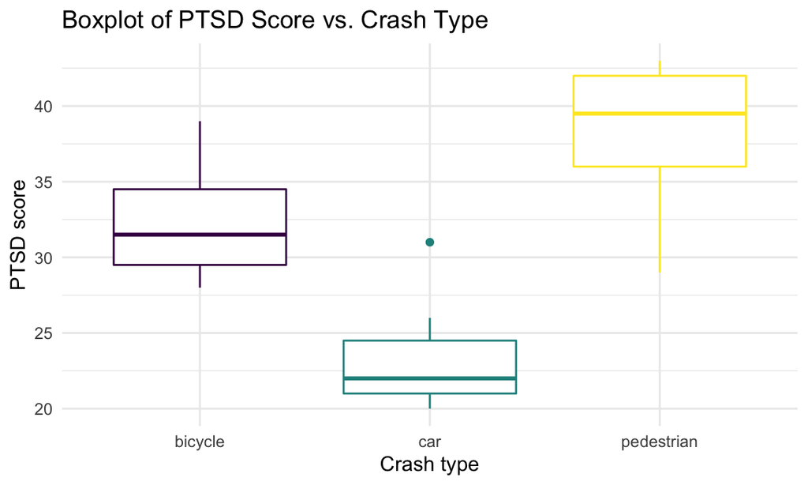

```r
crash_df %>%
  group_by(crash_type) %>%
  ggplot(aes(x = crash_type, y = PTSD_score, color = crash_type)) +
  geom_boxplot() +
  theme(legend.position = "none") +
  labs(
    title = "Boxplot of PTSD Score vs. Crash Type",
    x = "Crash type",
    y = "PTSD score"
  )
```

Measures of **Location** and **Dispersion** for each group:

```r
raw_df %>%
  summary() %>%
  knitr::kable(align = "c")
```

|  | pedestrian | bicycle | car |
| --- | --- | --- | --- |
|  | Min. :29.00 | Min. :28.0 | Min. :20.00 |
|  | 1st Qu.:36.00 | 1st Qu.:29.5 | 1st Qu.:21.00 |
|  | Median :39.50 | Median :31.5 | Median :22.00 |
|  | Mean :37.88 | Mean :32.5 | Mean :23.43 |
|  | 3rd Qu.:42.00 | 3rd Qu.:34.5 | 3rd Qu.:24.50 |
|  | Max. :43.00 | Max. :39.0 | Max. :31.00 |
|  | NA’s :2 | NA | NA’s :3 |

Also we can manually calculate `mean`, `sd` like this:

```r
crash_df %>%
  group_by(crash_type) %>%
  summarize(
    n = n(),
    mean = mean(PTSD_score),
    sd = sd(PTSD_score),
    sum = sum(PTSD_score)
  ) %>%
  knitr::kable(align = "c")
```

| crash_type | n | mean | sd | sum |
| --- | --- | --- | --- | --- |
| bicycle | 10 | 32.50000 | 4.062019 | 325 |
| car | 7 | 23.42857 | 3.866831 | 164 |
| pedestrian | 8 | 37.87500 | 5.436320 | 303 |

And manually calculate `median`, `quartiles` like this:

For `pedestrian`:

```r
## arranged data: 29 30 38 39 40 42 42 43

## Median
(39 + 40)/2
## [1] 39.5

## Q1 (25th percentile)
(30 + 38)/2
## [1] 34

## Q3 (75th percentile)
(42 + 42)/2
## [1] 42
```

For `bicycle`:

```r
## arranged data: 28 28 29 31 31 32 33 35 39 39

## Median
(31 + 32)/2
## [1] 31.5

## Q1 (25th percentile)
29
## [1] 29

## Q3 (75th percentile)
35
## [1] 35
```

For `car`:

```r
## arranged data: 20 21 21 22 23 26 31

## Median
22
## [1] 22

## Q1 (25th percentile)
(21 + 21)/2
## [1] 21

## Q3 (75th percentile)
(23 + 26)/2
## [1] 24.5
```

**(b) ANOVA Test**

Hypothesis:

$H_{0}: \mu_{1} = \mu_{2} = \mu_{3}, where\ \mu_{1}, \mu_{2}, \mu_{3} \ represents\ the\ mean\ of\ PTSD\ scores\ of\ 3\ crash\ types.$

$H_{1}: at\ least\ two\ means\ are\ not\ equal.$

```r
res1 = aov(PTSD_score ~ factor(crash_type), data = crash_df)
summary(res1)
```

```
##                    Df Sum Sq Mean Sq F value   Pr(>F)
## factor(crash_type)  2  790.4   395.2   19.53 1.33e-05 ***
## Residuals          22  445.1    20.2
## ---
## Signif. codes:  0 '***' 0.001 '**' 0.01 '*' 0.05 '.' 0.1 ' ' 1
```

The `test statistic` is $19.53$.

And for $n = 10 + 7 + 8 = 25$, $k = 3$, $\alpha = 0.01$.

Then the F critical value is:

```r
qf(0.99, df1 = 2, df2 = 22)
```

```
## [1] 5.719022
```

$F_{k-1, n-k, 1-\alpha} = F_{2, 22, 0.99} = 5.719$

Because $F = 19.53>F_{2, 22, 0.99} = 5.719$, reject the null hypothesis, and conclude that with pre-specified significant level of 0.01, at least two types of crash (among `car`, `bicycle` and `pedestrian`) have different mean PTSD scores.

**(c) Multiple Comparison**

```r
# use pairwise.t.test() for Bonferroni
pairwise.t.test(crash_df$PTSD_score, crash_df$crash_type, p.adj = 'bonferroni')
```

```
##
##  Pairwise comparisons using t tests with pooled SD
##
## data:  crash_df$PTSD_score and crash_df$crash_type
##
##            bicycle car
## car        0.0014  -
## pedestrian 0.0586  9.1e-06
##
## P value adjustment method: bonferroni
```

```r
# use Tukey
Tukey_comp = TukeyHSD(res1)
Tukey_comp
```

```
##   Tukey multiple comparisons of means
##     95% family-wise confidence level
##
## Fit: aov(formula = PTSD_score ~ factor(crash_type), data = crash_df)
##
## $`factor(crash_type)`
##                         diff          lwr       upr     p adj
## car-bicycle        -9.071429 -14.63967214 -3.503185 0.0013441
## pedestrian-bicycle  5.375000   0.01537946 10.734621 0.0492580
## pedestrian-car     14.446429   8.59860314 20.294254 0.0000088
```

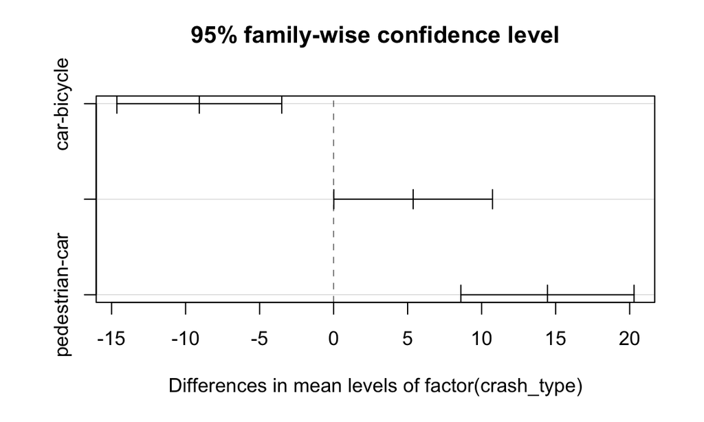

```r
plot(Tukey_comp)
```

```r
# use Dunnett's
```

[output not shown]

Though the accurate p-value may be slightly different among different methods, we can still conclude that:

1. The p-value between `pedestrian` and `car` group is around $9^{-6} \ll 0.05$, thus the mean PTSD scores between pedestrian crash and car crash are highly significantly different.
2. The p-value between `pedestrian` and `bicycle` group is around $0.05 \approx 0.05$, thus the mean PTSD scores between pedestrian crash and bicycle crash have NO significant difference.
3. The p-value between `car` and `bicycle` group is around $0.0014 \ll 0.05$, thus the mean PTSD scores between bicycle crash and car crash are highly significantly different.

**(d) Summary**

After analyzing the PTSD scores of 25 patients aging from 18-30 suffering from different types of crash (8 pedestrian crash, 10 bicycle crash and 7 car crash), we found that the mean PTSD scores are NOT statistically same among 3 crash types. Specifically, significant differences of mean PTSD scores have shown between `car crash` and `bicycle crash`, as well as between `car crash` and `pedestrian crash`, while there are NO significant difference between `pedestrian crash` and `bicycle crash`. Generally, we can conclude that the mean PTSD score of `car crash` is lower than other crash types.

## Problem 3

**(a) Justify Test**

I choose **Chi-Squared Test** to address this problem.

Since

1. Three treatment groups are independent random samples;
2. No expected cell counts are 0, and expected values in each cell $\ge 5$.

**(b) Table**

The table is given below:

```r
chi_table =
  tibble(
    Drug = c("Desipramine", "Lithium", "Placebo", "Total"),
    Relapse = c("15 (E = 17.67)", "18 (E = 17.67)", "20 (E = 17.67)", "53"),
    NOT_Relapse = c("18 (E = 15.33)", "15 (E = 15.33)", "13 (E = 15.33)", "46"),
    Total = c("33", "33", "33", "99")
  ) %>%
  knitr::kable(align = "c")

chi_table
```

| Drug | Relapse | NOT_Relapse | Total |
| --- | --- | --- | --- |
| Desipramine | 15 (E = 17.67) | 18 (E = 15.33) | 33 |
| Lithium | 18 (E = 17.67) | 15 (E = 15.33) | 33 |
| Placebo | 20 (E = 17.67) | 13 (E = 15.33) | 33 |
| Total | 53 | 46 | 99 |

About the `E` calculation process, for `Relapse` group, both are $\frac{(53 \times 33)}{99}$; and for `NOT Relapse` group, both are $\frac{(46 \times 33)}{99}$.

**(c) Hypothesis Test**

State the Hypothesis:

$H_{0}: the\ probability\ of\ a\ subject's\ relapse\ has\ NO\ association\ with\ the\ drug\ the\ subject\ was\ assigned\ to.$

$H_{1}: the\ probability\ of\ a\ subject's\ relapse\ is\ associated\ with\ the\ drug\ the\ subject\ was\ assigned\ to.$

With significant level $\alpha = 0.05$ pre-specified, compute the test statistic:

$\chi ^ 2 = \sum_{i = 1}^{3} \sum_{i = 1}^{2} \frac{(O_{ij} - E_{ij})^2}{E_{ij}}$

$= \frac{(15 - 17.67)^2}{17.67} + \frac{(18 - 17.67)^2}{17.67} + \frac{(20 - 17.67)^2}{17.67} + \frac{(18 - 15.33)^2}{15.33} + \frac{(15 - 15.33)^2}{15.33} + \frac{(13 - 15.33)^2}{15.33}$

$= 1.543$ $follows \ \chi ^ 2_{(3-1) \times (2-1) = 2} \ under \ H_{0}$

Critical Value:

```r
qchisq(0.95, df = 2)
```

```
## [1] 5.991465
```

$\chi ^ 2 _{2, 0.95} = 5.991$

For p-value:

```r
## Define data
drug_data = matrix(c(15, 18, 18, 15, 20, 13), nrow = 3,ncol = 2,byrow = T,
                  dimnames = list(c("Desipramine", "Lithium", "Placebo"),
                                  c("Relapse","NOT Relapse")))

# Perform test
chisq.test(drug_data)
```

```
##
##  Pearson's Chi-squared test
##
## data:  drug_data
## X-squared = 1.5431, df = 2, p-value = 0.4623
```

Thus the $p-value = 0.4623$.

Decision and Interpretation:

Given $\chi ^ 2 = 1.543 < \chi ^ 2 _{2, 0.95} = 5.991$, and $p-value = 0.4623 > 0.05$, we fail to reject $H_{0}$, and conclude that at the significance level of 0.05, there is no association between the probability of a subject’s relapse and the drug the subject was assigned to.